# Red Wine Quality Analysis

## Acidity and pH

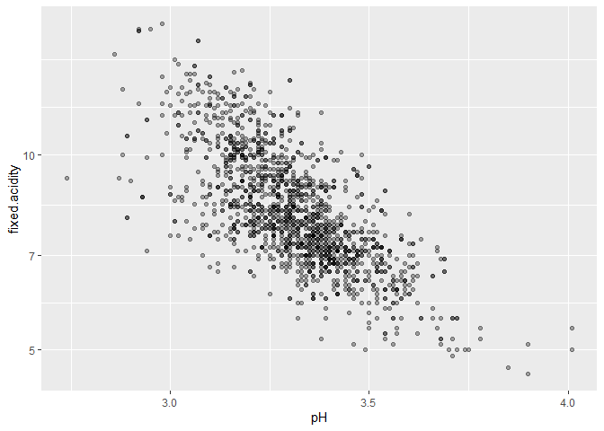

As the concentration of the acid decreases, the pH will increase. It is an inverse relationship, as expected for how pH is measured. Fixed acidity accounts for most acids present in the wine samples, so this trend would make sense.

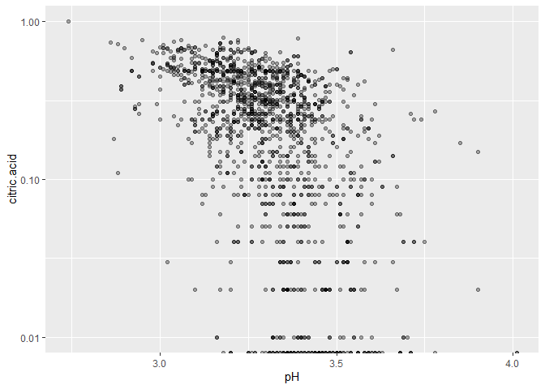

A similar relationship is seen with citric acid. But the citric acid is at lower concentrations, the relationship is not as prominent.

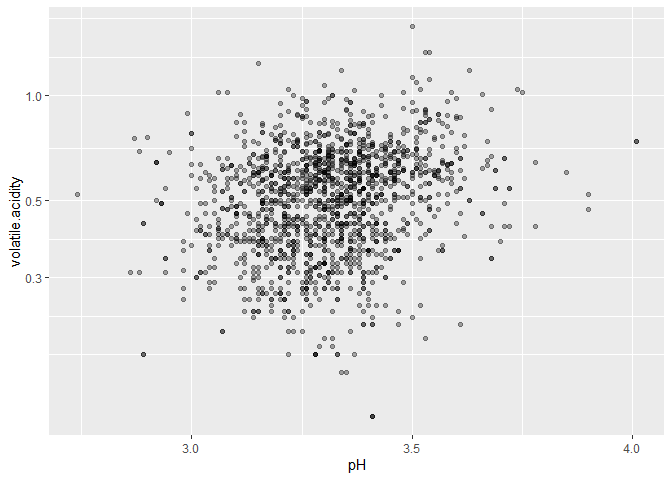

The volatile acidity seems to have little to no effect on the pH level.

The correlation coefficient for this is:

```
##
##  Pearson's product-moment correlation
##
## data:  pH and log10(volatile.acidity)
## t = 9.1468, df = 1597, p-value < 2.2e-16
## alternative hypothesis: true correlation is not equal to 0
## 95 percent confidence interval:
##  0.1760195 0.2691923
## sample estimates:
##       cor
## 0.2231154
```

The correlation coefficient shows a weak positive correlation of how the volatile acidity impacts the pH. Maybe when the volatile acids are present in higher concentrations, the concentration of the remaining acids is lower and that contributes to the increased level of the pH.

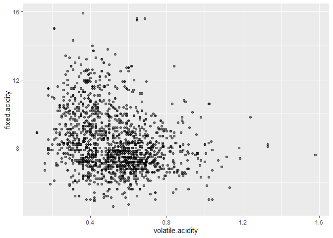

```
##
##  Pearson's product-moment correlation
##
## data:  fixed.acidity and volatile.acidity
## t = -10.589, df = 1597, p-value < 2.2e-16
## alternative hypothesis: true correlation is not equal to 0
## 95 percent confidence interval:
##  -0.3013681 -0.2097433
## sample estimates:
##        cor
## -0.2561309
```

There is a weak negative correlation here. On the plot, both variables seem to have a natural limit on the lower sides of the data. We have seen on the univariate plots that both are right skewed as well.

## Density, Sugar and Alcohol Content

The density of wine should be close to that of the density of water, and will change depending on the percent of alcohol and sugar content as was explained in the initial information given with the dataset.

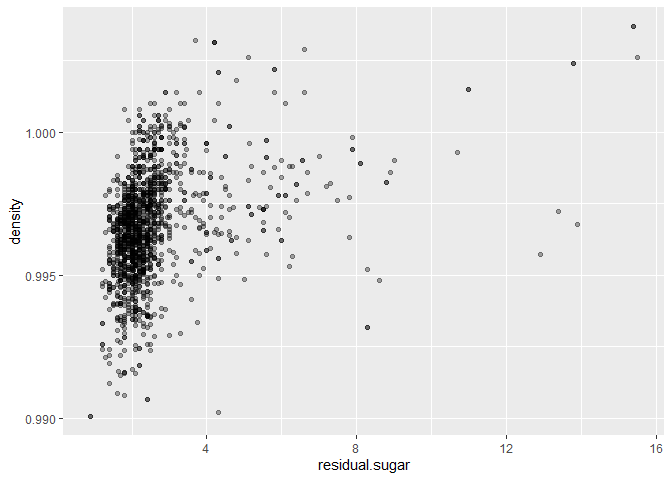

And here is a zoomed in look:

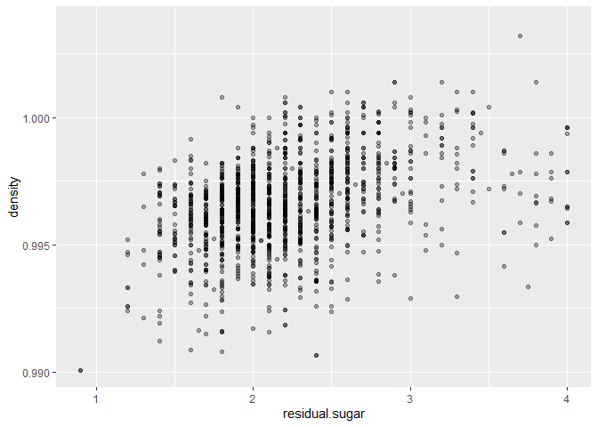

There seems to be an increase in density as there is an increase of residual sugar.

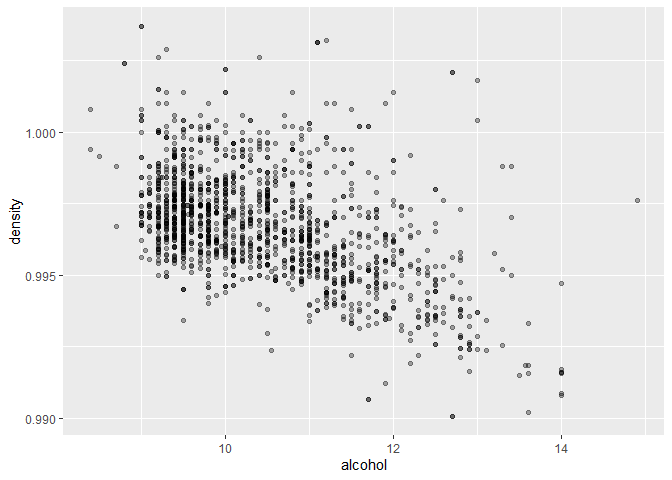

And there seems to be a decrease of density with an increase in the alcohol content of the wine.

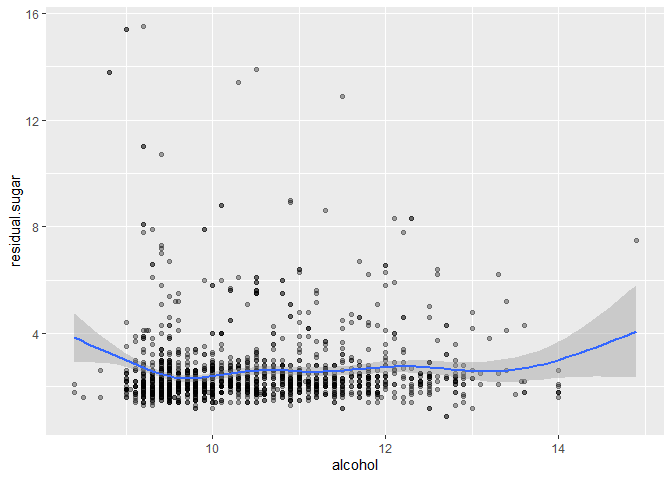

And now taking a zoomed look at it:

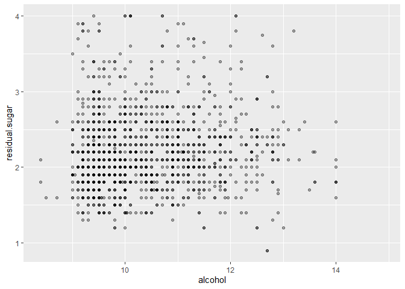

```
##
##  Pearson's product-moment correlation
##
## data:  residual.sugar and alcohol
## t = 1.6829, df = 1597, p-value = 0.09258
## alternative hypothesis: true correlation is not equal to 0
## 95 percent confidence interval:
##  -0.006960058  0.090909069
## sample estimates:
##        cor
## 0.04207544
```

It was expected that a stronger correlation between the alcohol content and the residual sugar would be shown, since the alcohol should be coming from the fermentation of the sugars.

Possible some of the wines are fortified with extra alcohol added after the fermentation process, or the yeast behaves in such a way that do not allow the data to establish a linear relationship between sugar fermentation and alcohol production. There is also the fact that the data does not mention which types of grapes were used, which may have different sugar contents that could impact this relationship.

## Sulphates and sulfur oxide

The sulphates are an additive which can contribute to sulfur dioxide gas levels in wine.

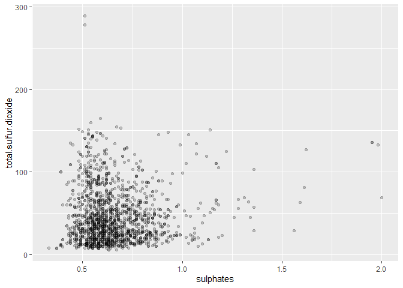

Compare this to free sulfur dioxide:

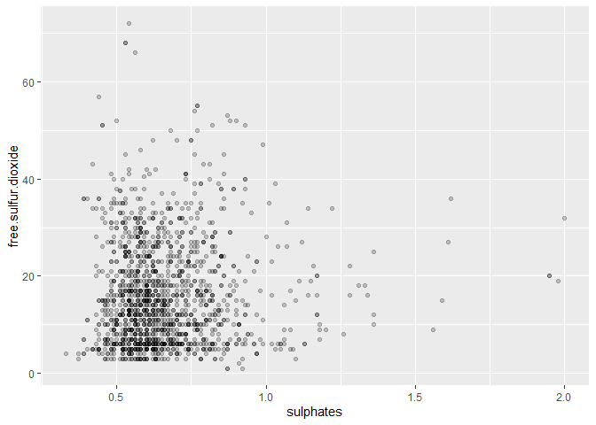

Checking the correlation between total sulfur dioxide levels with sulphates:

```
##
##  Pearson's product-moment correlation
##
## data:  total.sulfur.dioxide and sulphates
## t = 1.7178, df = 1597, p-value = 0.08602
## alternative hypothesis: true correlation is not equal to 0
## 95 percent confidence interval:
##  -0.006087119  0.091774762
## sample estimates:
##        cor
## 0.04294684
```

And now checking the correlation between the free sulfur dioxide levels with sulphates:

```
##
##  Pearson's product-moment correlation
##
## data:  free.sulfur.dioxide and sulphates
## t = 2.0671, df = 1597, p-value = 0.03888
## alternative hypothesis: true correlation is not equal to 0
## 95 percent confidence interval:
##  0.002643125 0.100424406
## sample estimates:
##        cor
## 0.05165757
```

The relationship between the sulphates levels and sulfur dioxide is pretty weak.

# Bivariate Analysis

**Talk about some of the relationships you observed in this part of the investigation. How did the feature(s) of interest vary with other features in the dataset?**

The wine quality rating is higher and has a stronger relationship with the 4 variables of volatile acidity, citric acid, sulphates and alcohol content. The correlation coefficients show that the strength of the relationship with the variables is shown below.

```
##                             [,1]
## fixed.acidity         0.11408367
## volatile.acidity     -0.38064651
## citric.acid           0.21348091
## residual.sugar        0.03204817
## chlorides            -0.18992234
## free.sulfur.dioxide  -0.05690065
## total.sulfur.dioxide -0.19673508
## density              -0.17707407
## pH                   -0.04367193
## sulphates             0.37706020
## alcohol               0.47853169
```

For the free and total sulfur dioxide variables, in the plots already explored it was shown that the medium quality ratings (5 and 6) have both higher content than the low and higher quality ratings. This may indicate that there is some interaction with the other variables.

**Did you observe any interesting relationships between the other features (not the main feature(s) of interest)?**

The expected relationship between the pH level and acidity level was as expected.

It was of interest to observe the relationship between the density and the alcohol and sugar concentration of the wine.

It was unexpected to not find a stronger relationship between the residual sugar and alcohol concentration, since the alcohol should in theory come from the fermentation of sugars in the wine making process.

**What was the strongest relationship you found?**

The correlation coefficients show that the variable with the strongest relationship with quality rating is the alcohol concentration.

# Multivariate Plots Section

## Correlation Matrix

Here is a matrix of the correlations in the data:

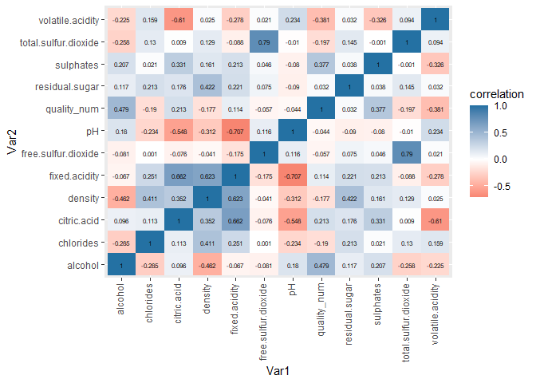

## Alcohol, volatile acidity and quality

Quality strongly correlates with alcohol and volatile acidity. Volatile acidity seems to come from acetic acid which can give an unpleasant taste to the wine.

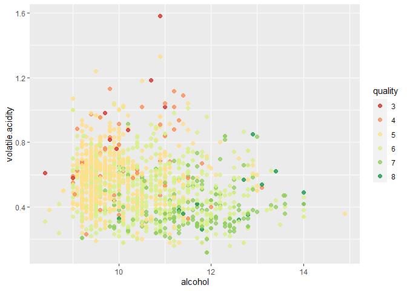

The lowest quality wines have a low alcohol and high volatile acidity concentration. The middle quality wines (rated 5 and 6) can seem to be found spread throughout the plot area.

## Acidity, pH, quality

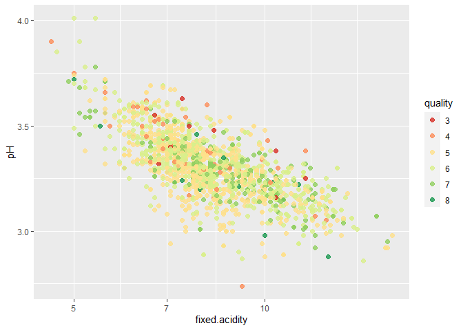

There does not seem to be much of a pattern in the quality ratings distribution in this plot.

## Citric acid, alcohol, quality

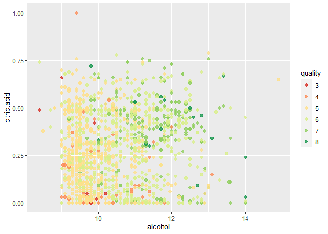

The increase of both citric acid and alcohol concentrations tends to give a higher quality wine rating. But there is also wines with a quality rating of 5 on a wide range of citric acid concentrations as well as at low alcohol concentrations. There are also high quality rated wines with low citric acid concentrations.

## Alcohol and Sulphates

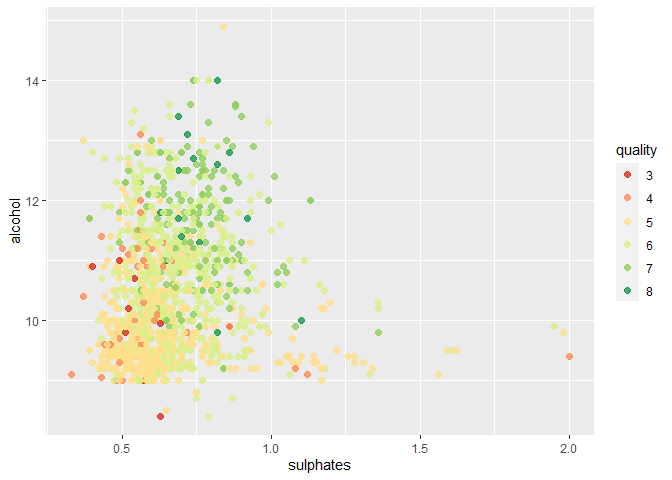

And here is the same but zoomed in:

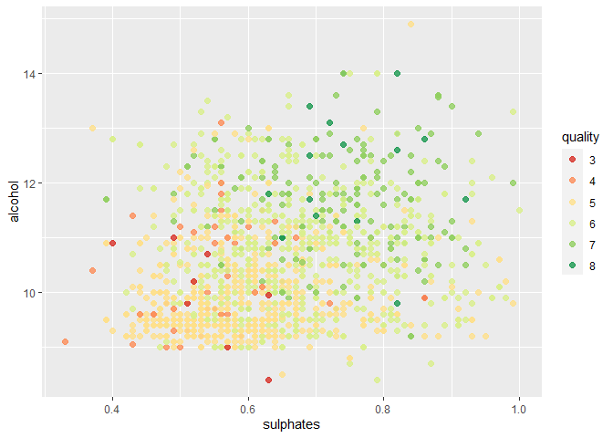

Alcohol and sulphates appear to have a positive correlation, and higher alcohol combined with higher sulphates concentrations yields a higher quality wine rating for the range of sulphates between 0 and 1.

```
##
##  Pearson's product-moment correlation
##
## data:  alcohol and sulphates
## t = 3.7568, df = 1597, p-value = 0.0001783
## alternative hypothesis: true correlation is not equal to 0
## 95 percent confidence interval:
##  0.04477906 0.14196454
## sample estimates:
##        cor
## 0.09359475
```

# Multivariate Analysis

**Talk about some of the relationships you observed in this part of the investigation. Were there features that strengthened each other in terms of looking at your feature(s) of interest?**

The main relationships explored were between the biggest correlations with quality.

It has been shown how alcohol and volatile acidity relate to quality. Higher alcohol and lower acidity concentrations give a typically better wine rating for quality.

Higher amounts of citric acid combined with higher alcohol content also typically give a better wine rating for quality.

There is also a trend to have a better quality rating for the wine with both the alcohol and the sulphates are higher.

# Final Plots and Summary

### Plot One

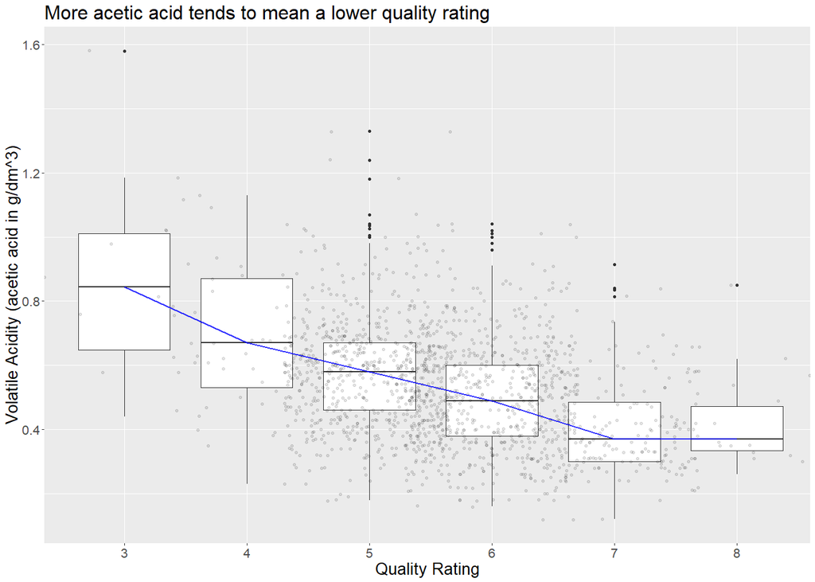

**Description One**

Here is the distribution of volatile acidity across the different quality ratings. The boxplot shows the quantile boundaries and median values, while the overlapping dots shows the actual distribution of the wine samples. There is an unbalanced amount between the middle ratings and the higher and lower quality ratings. There are much more middle quality rated wines than there are low and high quality rated wines. The line connects the median values and helps to show visually the decreasing trend of volatile acidity with quality rating. Wines with lower volatile acidity tend to be rated higher in quality.

### Plot Two

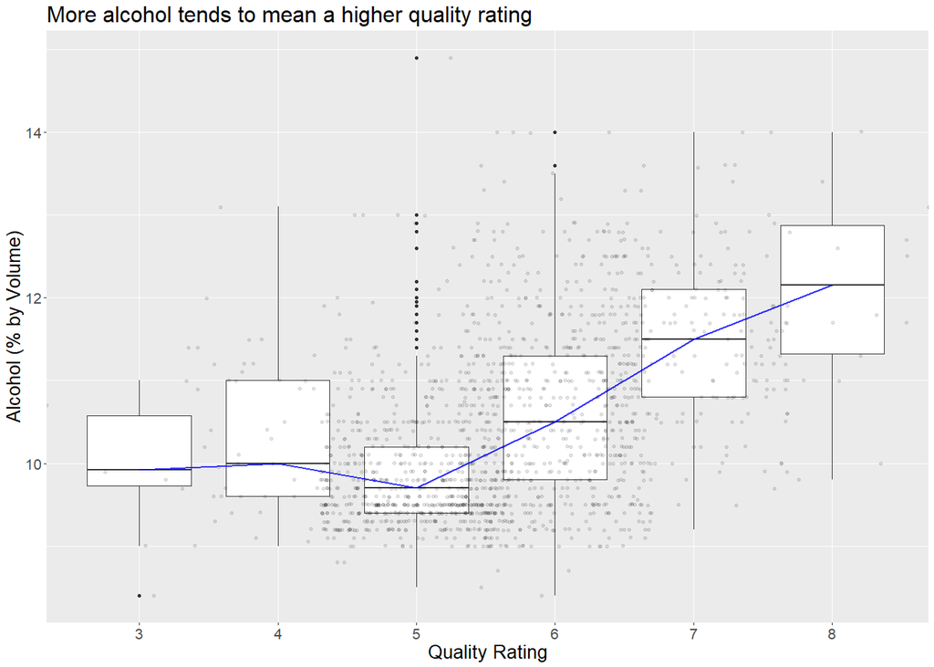

**Description Two**

Alcohol seems to have a significant relationship to the rated quality of the wines. For the quality ratings of 3 to 5, the effect seems to be somewhat limited. The quality rating is likely being impacted by another variable at these rating levels, but from the quality ratings of 5 to 8, there seems to be a higher increase in the alcohol concentration of the wine samples. There is a general trend that wines with a higher alcohol concentration will have a higher rated quality rating.

### Plot Three

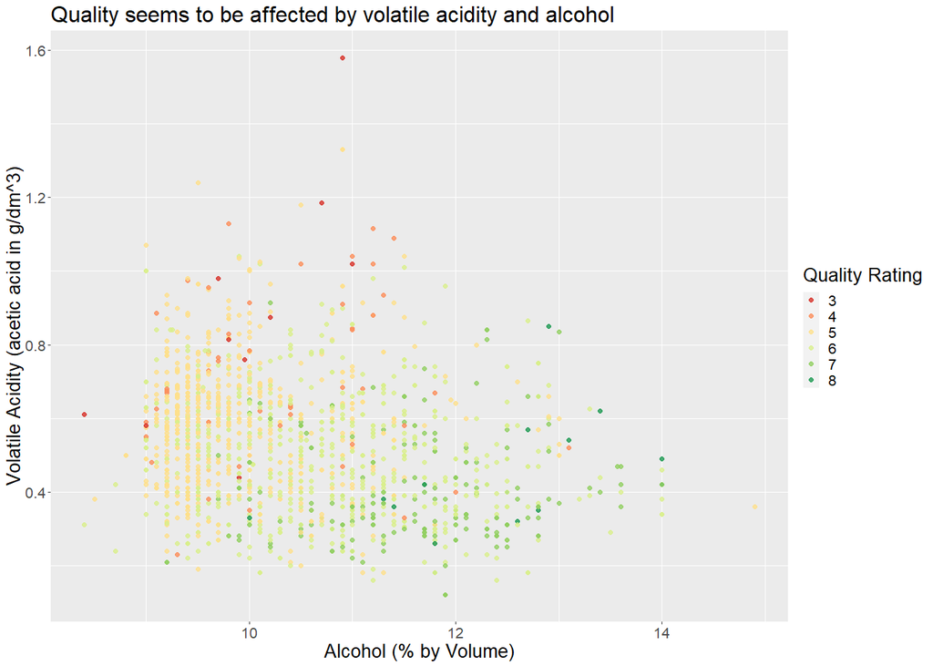

**Description Three**

In the analysis, it has been shown that it appears that alcohol and volatile acidity play significant roles on the quality rating a wine will receive. Using this plot, it can be seen that there does seem to be a trend that the lower a wine’s concentration of volatile acidity and the higher its alcohol concentration, the higher it is likely the wine sample will rate for its quality rating. There is also visible the inverse trend, that wine samples with a high concentration of volatile acidity and low alcohol concentration, the lower rating that wine sample will likely be for its quality rating.

# Reflection

This project allowed the exploration of a real life dataset using the knowledge of using R. The dataset was already organized and tidy, so it was ideal to focus on analyzing the data and exploring it without having to go through the tedium that sometimes accompanies data cleaning.

Working with datasets has the challenge of deciding how to approach the exploration of the data. Because this dataset also came with a description file, it already outlined some possible variables that might lend themselves to exploration. This proved quite useful. For example, when the description file said that citric acid could add a freshness element to the taste of wines, while acetic acid would add an almost vinegar like taste, this provided context to many of the observations that would follow. This also shows just how important it is to have some knowledge of the subject matter when beginning an analysis, as some contexts could be lost on a casual observer. This knowledge helps structure the approach to the analysis, and allows better theory formation so that meaningful insights can be gotten from the data processing.

Another challenge faced was figuring out how to communicate with the multivariate plots. When adding a third dimension to a plot, mentally visualizing that can become harder for individuals. Use of color helped with this challenging approach, which made it easier to grasp what information was being communicated by each step of the analysis, adding in clarity and depth of information.Using the correlation matrix was a neat addition that was quite welcome.This also helped to narrow down which variables should be focused on for further exploration. Overall, data needs to be communicated in such a way that its story can easily be understood and followed for the reader, so putting extra effort into making it legible proved a good use of time.

As a way to expand the analysis, bringing in other different types of wines would be an interesting way to see if the trends are strengthened, or weakened, with this new data. Expanding the dataset with the same type of wine, but simply having more observations would also be interesting, as the dataset used in this analysis was not very large. It would also be of interest if some additional variables could be added to the total dataset, such as type of grape, location grown, and how long before the grape was harvested.

In summary, having found and explored the main relationships in the dataset, using these trends to predict how other wines would fare as to their quality rating would be a logical next step. Then gathering data from those observations made on the predicted trends could be made to further refine the process of the prediction in the future.

# Refrences

P. Cortez, A. Cerdeira, F. Almeida, T. Matos and J. Reis. Modeling wine preferences by data mining from physicochemical properties. In Decision Support Systems, Elsevier, 47(4):547-553. ISSN: 0167-9236.

Available at: [@Elsevier] http://dx.doi.org/10.1016/j.dss.2009.05.016 [Pre-press (pdf)] http://www3.dsi.uminho.pt/pcortez/winequality09.pdf [bib] http://www3.dsi.uminho.pt/pcortez/dss09.bib

StackOverflow website for various questions and research. Available at: http://www.Stackoverflow.com

R Bloggers website for various guides to using R, including a correlation heatmap. Available at: http://www.r-bloggers.com

R Markdown website by RStudio Available at: https://rmarkdown.rstudio.com/authoring_pandoc_markdown.html